# CSCI E-63C Week 8 Assignment

# Problem 4: Brute force randomization in hierarchical clustering (15 points)

Compare distribution of the heights of the clusters defined by `hclust` with Ward’s clustering of Euclidean distance between countries in scaled WHS dataset and those obtained by applying the same approach to the distances calculated on randomly permuted WHS dataset as illustrated in the lecture slides. Discuss whether results of such brute force randomization are supportive of presence of unusually close or distant sets of observations within WHS data.

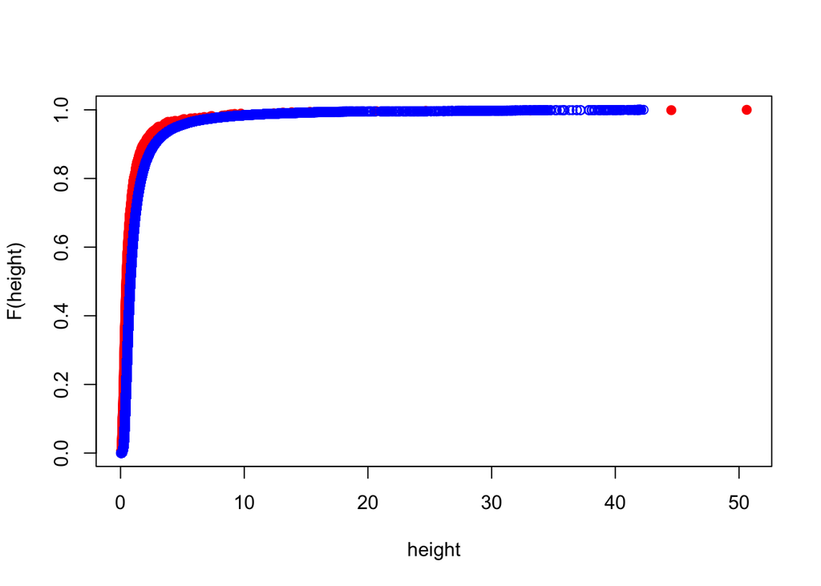

```r
dat.1 <- s.whs

ori.heights = hw.1$height
rnd.heights = numeric()
for ( i.sim in 1:100 ) {
   data.rnd <-apply(data.1,2,sample)
   hw.rnd=hclust(dist(data.rnd),method="ward.D2")
   rnd.heights <- c(rnd.heights,hw.rnd$height)
}
plot(ori.heights,rank(ori.heights)/length(ori.heights),
   col="red",xlab="height",ylab="F(height)",pch=19)
points(rnd.heights,rank(rnd.heights)/length(rnd.heights),
   col="blue")
```

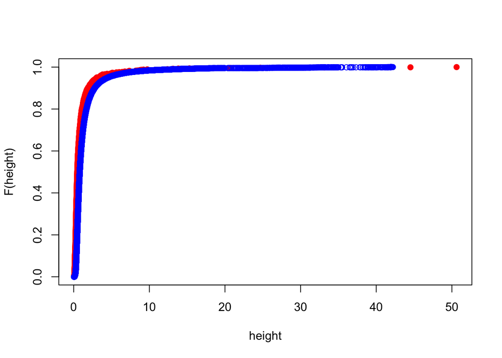

```r
dat.1 <- s.quakes

ori.heights = hw.1$height
rnd.heights = numeric()
for ( i.sim in 1:100 ) {
   data.rnd <-apply(data.1,2,sample)
   hw.rnd=hclust(dist(data.rnd),method="ward.D2")
   rnd.heights <- c(rnd.heights,hw.rnd$height)
}
plot(ori.heights,rank(ori.heights)/length(ori.heights),
   col="red",xlab="height",ylab="F(height)",pch=19)
points(rnd.heights,rank(rnd.heights)/length(rnd.heights),
   col="blue")
```